[figure not shown]

# Módulos y bibliotecas en Python

Hasta ahora hemos desarrollado programas no muy complicados que cabían en una celda de un Notebook, pero poco a poco se va complicando más la cosa. ¿Qué ocurrirá cuando tengamos varias Clases definidas, funciones, datos declarados, llamadas a paginas web...? ¿Lo vamos a tener todo en una celda/Notebook? Para ayudarnos con esto utilizaremos la sentencia `import`, pudiendo dividir nuestro programa en varios scripts de Python, y no solo eso, sino que tendremos también la opción de usar librerías de terceros en nuestro código, lo que va a ayudar mucho en el desarrollo.

Para este Notebook se recomienda tener otro IDE como VSCode, Spyder o Pycharm.

1. import
2. Bibliotecas
3. Resumen

## 1. import

Recuerda que hay que **evitar en la medida de lo posible tener código repetido o duplicado**, por lo que funcionalidades que uses en diferentes partes del código no tendrás que copiar y pegarlas en todos lados, sino que existe la posibilidad de definirlas una sola vez, e importarlas después.

Por tanto, según vamos complicando nuestros programas, surge la necesidad de modularizarlo, es decir, poder dividirlo y paquetizarlo. Como habrás podido imaginar, programas productivos como una página web o un juego, no van en un Notebook, sino en varios scripts de Python. Según las diferentes funcionalidades del código, lo iremos dividiendo en varias partes. Por ejemplo, en un script pueden ir funciones auxiliares, en otro constantes, en otro tus Clases... Veamos algunos conceptos

**Script**

No es más que un archivo con código Python. Estos archivos tienen la extensión `.py`, por lo que un ejemplo podría ser `primer_script.py`.

**Módulo/Biblioteca/Librería/Paquete**

Son términos parecidos que se suelen utilizar para referirse a lo mismo. A efectos prácticos, los consideraremos igual. Se trata de paquetes de código que tienen una funcionalidad bien definida y podremos importar en nuestros programas de Python, utilizando lo que haya dentro (clases, funciones, variables...).

**import**

Palabra reservada y sentencia que se usa en Python para importar cualquier objeto en nuestro código. Se usa para importar variables, funciones o módulos.

Veamos cómo podemos importar objetos de otros scripts

```python
%%file primer_script.py
"""
Example of a python module. Contains a variable called my_variable,
a function called my_function, and a class called MyClass.
"""

my_variable = 0

def my_function() -> int:
    """
    Example function
    """
    return my_variable

class MyClass:
    """
    Example class.
    """

    def __init__(self):
        self.variable = my_variable

    def set_variable(self, new_value: int) -> None:
        """
        Set self.variable to a new value
        """
        self.variable = new_value

    def get_variable(self) -> int:
        return self.variable
```

Tenemos en otro script una variable, una función y una clase definida. Ahora lo importamos

```python
import primer_script
help(primer_script)
```

Como siempre en cualquier lenguaje de programación **tenemos que fijarnos siempre dónde está apuntando el Notebook**, es decir, en qué directorio de trabajo va a leer el script. Al poner `import primer_script`, va a buscar ese script en el **mismo directorio donde esté el Notebook**. Si lo tenemos en otro lado del ordenador, no lo detectará. Cuando realizas el importado Python no recorre todas las carpetas del ordenador, lo busca en el mismo sitio donde está el Notebook. Más delante veremos cómo leer scripts de otros directorios.

Si queremos acceder a cualquier objeto del módulo, simplemente utilizamos la sintaxis `nombre_modulo.objeto`

```python
print(primer_script.my_variable)
print(primer_script.my_function)
print(primer_script.MyClass)
```

```python
new_object = primer_script.MyClass()
print(new_object)
print(new_object.get_variable())
```

[Aquí](https://docs.python.org/3/reference/import.html) tienes el enlace a la documentación del `import` por si tienes dudas, o necesitas realizar operaciones más complejas con el importado de módulos.

[figure not shown]

### ERRORES Importado de módulos

Típico error cuando intentamos acceder a un módulo que pensamos que está instalado en el intérprete de Anaconda, o queremos acceder a un *.py* que en realidad no está en la ruta deseada.

```python
import mi_modulo
```

O si intentamos acceder una función/atributo que en realidad no existe en el módulo.

```python
primer_script.my_function2()
```

[figure not shown]

### Crear un script

Crea un nuevo script de Python (es un archivo .py) y ponle de nombre "ejer_prueba.py". Lo puedes crear desde el propio Jupyter Lab desde File -> New -> Text File. O también desde VSCode/Pycharm Declara dos variables en el script a = 1 b = 2

Importa ambas variables e imprimelas por pantalla.

NOTA: si estás seguro de que está bien y no te reconoce las variables, prueba a reiniciar el kernel.

```python
import ejer_prueba

print(ejer_prueba.a)
print(ejer_prueba.b)
```

Tienes otras maneras de importar datos, ya que en ocasiones desconocemos lo que hay dentro del módulo, o simplemente no queremos utilizar todo lo que hay.

```python
from primer_script import my_variable
print(my_variable)
```

```python
from math import pi
print(pi)
```

En este caso ya no es necesario usar la sintaxis `modulo.objeto`, sino que el objeto ya está cargado en memoria. Es como si lo hubiésemos ejecuctado en una celda.

Otra opción es importar todo. **NO es lo recomendable**. Porque el módulo podría tener muchas variables o funciones que no necesitemos, y ocupan espacio en memoria.

```python
from primer_script import *
```

**¿Y si tenemos el archivo en otra carpeta?** La sintaxis es la misma. Si dentro de la carpeta donde está el Notebook, hay otra carpeta llamada `direc_segundo`, y dentro de esa carpeta hay otro script llamado `segundo_script.py`, podrás acceder a los objetos de ese escript mediante la sintaxis `import direc_segundo.segundo_script`

[figure not shown]

### Crear un script dentro de una carpeta

En el mismo sitio donde se encuentra este Notebook, crea la carpeta "direc_segundo", y dentro de la carpeta crea otro script llamado "segundo_script.py". Declara dos variables en el script c = 3 d = 4

Importa ambas variables e imprimelas por pantalla.

```python
import direc_segundo.segundo_script as ss

print(ss.c)
print(ss.d)
```

```python
import direc_segundo.otro_folder.segundo_script_2 as ss2

print(ss2.c)
print(ss2.d)
```

En estos casos resulta muy útil ponerle un alias al `import`. Esto nos ayudará a acortar el nombre y a poner uno más intuitivo

```python
import direc_segundo.segundo_script as variables
print(variables.c)
```

Por útimo, **¿y si nuestros módulos no están en una carpeta dentro del proyecto donde estamos trabajando, sino en otra carpeta del ordenador, o en directorios anteriores?** Esto lo podemos solucionar mediante `sys.path`. `sys` es el módulo de Python que se usa para manejar las variables del sistema y el intérprete. Y `path` es una lista de strings con una serie de rutas donde acude el intérprete de Python cuando tiene que buscar un módulo. [Tienes aqui la documentación de `sys`](https://docs.python.org/3/library/sys.html)

```python
import sys
sys.path
```

Si queremos que el intérprete de Python entienda de otros módulos que **no están en la carpeta de Notebook**, tendremos que añadir esa ruta a la lista de paths mediante la sintaxis `sys.path.append(la_nueva_ruta)`. Recuerda que `sys.path` es una lista, por lo que podrás aplicarle lo que ya sabes sobre listas.

[figure not shown]

### Añadir un nuevo path

Crea un nuevo directorio en otra ruta del ordenador, por ejemplo en el escritorio. Llámalo "direc_tercero" e introduce dentro un nuevo script que se llame "tercer_script.py". Tendrás que añadir el path de ese directorio a los paths de sys. Declara dos variables en el script e = 5 f = 6

Importa ambas variables e imprimelas por pantalla.

```python
import tercer_script
print(tercer_script.e)
print(tercer_script.f)
```

```python
# sys.path.append('C:\\Users\\Miguel Angel\\Desktop\\direc_tercero')
sys.path
```

Una vez creado el nuevo directorio, se recomienda copiar su ruta y pegarla en el `append`

[figure not shown]

Con lo visto en este Notebook tienes conocimiento de sobra para manejar tu programa en varios scripts, pero si quieres aprender más sobre el concepto `import`, te recomiendo que te leas [este artículo](https://chrisyeh96.github.io/2017/08/08/definitive-guide-python-imports.html).

## 2. Bibliotecas

Hasta ahora, todas las funcionalidades que necesitabas en Python las has ido desarrollando con tu propio código. Esto está bien, pero no siempre es necesario. **Existen muchísimas librerías que pueden hacer el trabajo por ti**, por lo que antes de implementar algo, **no reinventes la rueda**. Se listo y busca si ya hay algo hecho en la web. Esto es lo bueno de trabajar con un lenguaje open source, que existe una comunidad con muchísimos desarrolladores y hay una gran cantidad de código publicado de manera gratuita. Por tanto, ¿De dónde podemos sacar estos códigos mágicos?

- **[Biblioteca estándar de Python](https://docs.python.org/3/library/index.html#the-python-standard-library)**: aqui tienes muchas de las cosas que hemos visto ya (tipos de datos, el móduglo math...) y mucho más (lectura de archivos, compresión, acceso a BBDD...).
- **Bibliotecas de terceros**: librerías que no vienen en el paquete por defecto de Python. Estas librerías o bien las implementa un particular o una empresa, y son de código abierto. Anaconda está muy orientado a la ciencia de datos, por lo que tiene librerías muy interesantes que utilizaremos durante el curso (pandas, numpy o sklearn). Además de estás librerías, podrás añadir al intérprete de Python todas las que necesites

Veamos un ejemplo de importación de una librería

```python
import math
math.sqrt(36)
```

Importando `math`, podremos acceder a todas sus funciones mediante la sintaxis `math.funcion()`. [En la documentación](https://docs.python.org/3/library/math.html#math.log) verás todo lo que puedes hacer con `math`.

Veamos un ejemplo en el que nos ayude a no escribir código de más.

```python
help(math)
```

```python
help(math.sqrt)
```

```python
print(dir(math))
```

Otro ejemplo en el que vemos la potencia de `pandas`, a la hora de leer archivos

```python
import csv

with open('datos_prueba.csv', 'r') as file:
    my_reader = csv.reader(file, delimiter = ',')

    for row in my_reader:
        print(row)

print("Fin")
```

```python
import pandas as pd

mi_data = pd.read_csv("datos_prueba.csv")
mi_data.head()
```

|  | schedtime | carrier | deptime | dest | distance | date | flightnumber | origin | weather | dayweek | daymonth | tailnu | delay |
| --- | --- | --- | --- | --- | --- | --- | --- | --- | --- | --- | --- | --- | --- |
| 0 | 1455 | OH | 1455 | JFK | 184 | 1/1/2004 | 5935 | BWI | 0 | 4 | 1 | N940CA | ontime |
| 1 | 1640 | DH | 1640 | JFK | 213 | 1/1/2004 | 6155 | DCA | 0 | 4 | 1 | N405FJ | ontime |
| 2 | 1245 | DH | 1245 | LGA | 229 | 1/1/2004 | 7208 | IAD | 0 | 4 | 1 | N695BR | ontime |
| 3 | 1715 | DH | 1709 | LGA | 229 | 1/1/2004 | 7215 | IAD | 0 | 4 | 1 | N662BR | ontime |
| 4 | 1039 | DH | 1035 | LGA | 229 | 1/1/2004 | 7792 | IAD | 0 | 4 | 1 | N698BR | ontime |

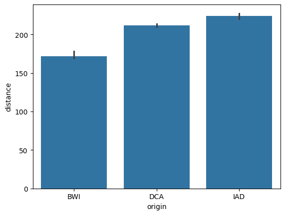

```python
import seaborn as sns

sns.barplot(x = "origin", y = "distance", data = mi_data)
```

### Bibliotecas de terceros

**¿Y si encontramos una librería interesante, pero no viene en el paquete de Anaconda?** La podremos instalar. Anaconda viene con muchas bibliotecas ya instaladas, la mayoría orientadas a trabajar con datos, pero por supuesto, no contiene todas las bibliotecas. Si quieres ver los paquetes de Anaconda, abre un *Prompt de Anaconda* y escribe `pip freeze`.

Entonces, **¿cómo se instala un paquete nuevo?** La mayoría de paquetes los vas a encontrar en [PyPI (Python Package Index)](https://pypi.org), que es el repositorio oficial de paquetes de Python. Existen paquetes de particulares (no empresas, ni comunidades) en PyPI. Eso no quiere decir que no los puedas instalar, sino que probablemente estén menos testados que los "oficiales".

Veamos un ejemplo de cómo instalar una nueva librería. En este caso, instalaremos **wget**, que nos sirve para obtener archivos de la web.

```python
!pip freeze
```

```
asttokens==2.4.0
backcall==0.2.0
colorama==0.4.6
comm==0.1.4
contourpy==1.1.1
cycler==0.12.1
debugpy==1.8.0
decorator==5.1.1
executing==1.2.0
fonttools==4.43.1
ipykernel==6.25.2
ipython==8.15.0
jedi==0.19.0
jupyter_client==8.3.1
jupyter_core==5.3.1
kiwisolver==1.4.5
matplotlib==3.8.0
matplotlib-inline==0.1.6
nest-asyncio==1.5.8
numpy==1.26.0
packaging==23.1
pandas==2.1.1
parso==0.8.3
pickleshare==0.7.5
Pillow==10.0.1
platformdirs==3.10.0
prompt-toolkit==3.0.39
psutil==5.9.5
pure-eval==0.2.2
Pygments==2.16.1
pyparsing==3.1.1
python-dateutil==2.8.2
pytz==2023.3.post1
pywin32==306
pyzmq==25.1.1
seaborn==0.13.0
six==1.16.0
stack-data==0.6.2
tornado==6.3.3
traitlets==5.10.0
tzdata==2023.3
wcwidth==0.2.6
```

```python
!where python
```

```
c:\Users\jaime\AppData\Local\Programs\Python\Python311\python.exe
C:\Users\jaime\AppData\Local\Microsoft\WindowsApps\python.exe
```

```python
import wget
```

Al hacer el `import`, no existe, por lo que tendremos que instalarla. Para instalarla, abre un prompt de Anaconda y ejecuta `pip install wget`

[figure not shown]

```python
!pip install wget
```

[output not shown]

```python
import wget

url = 'http://www.futurecrew.com/skaven/song_files/mp3/razorback.mp3'
filename = wget.download(url)
filename
```

```
'razorback.mp3'
```

## 3. Resumen

Como ves, **gran parte de la potencia de Python reside en sus librerías**. Combinando los conocimientos ya aprendidos con las librerías adecuadas, podremos crear dashboards interactivos, modelos de machine learning, páginas webs, automatizar procesos... ¡Los límites los pones tu! :)

```python
# Sintaxis básica para importar un modulo
import primer_script

# PAra acceder a su documentación
help(primer_script)

# PAra acceder a los objetos del modulo
print(primer_script.my_variable)
print(primer_script.my_function)
print(primer_script.MyClass)

# Una manera de acceder a todo
from primer_script import *

# Renombrar el modulo también es util
import direc_segundo.segundo_script as variables
print(variables.c)

# Si queremos acceder rutas en otras partes del ordenador, hay que añadirlas a sys.path
sys.path.append('C:/Users/Daney/Desktop/direc_tercero')
sys.path

# Por otro lado, tenemos las librerías del estandar de Python
import math
math.sqrt(36)

# O librerias de terceros que podrás instalar mediante un pip install libreria, en un Prompt de Anaconda.
import wget
```

```python
# https://towardsdatascience.com/dont-use-python-os-library-any-more-when-pathlib-can-do-141fefb6bdb5
```